# Project 3 - Relational Database

A. Joshua Bentley, John K. Hancock, and Chester Poon

# Overview

In order to load the data we scraped from the three different websites, we’ll first clean our data. The following would need to be done:

- Unify the variable names so that each variable has only one name
- Clean the data where necessary
- Create separate data frames for each normalized table
- Load our data frames as a table into our SQLite database

First we’ll load the libraries we’ll use to clean up, prepare our data, and create our database.

```r
library(dplyr)
library(DBI)
library(RSQLite)
library(ggplot2)
```

# Cleaning Our Data

### LinkedIn

Let’s load the LinkedIn csv file from our web scrape and take a quick glance.

```r
linkedin <- read.csv('LinkedIn.csv', stringsAsFactors = FALSE)
knitr::kable(head(linkedin), format = "html")
```

| industry | skills | title | job_id |
| --- | --- | --- | --- |
| Marketing and Advertising | Python (Programming Language) | Data Scientist | LI1 |
| Marketing and Advertising | Data Science | Data Scientist | LI1 |
| Marketing and Advertising | Artificial Neural Networks | Data Scientist | LI1 |
| Marketing and Advertising | Deep Learning | Data Scientist | LI1 |
| Marketing and Advertising | Google Cloud Platform (GCP) | Data Scientist | LI1 |
| Marketing and Advertising | Machine Learning | Data Scientist | LI1 |

Looks mostly clean already. We’ll add another column to identify the source of the data, which we’ll also do for the other two data sets.

```r
linkedin <- linkedin %>%
  mutate(website = "linkedin.com")

knitr::kable(head(linkedin), format = "html")
```

| industry | skills | title | job_id | website |
| --- | --- | --- | --- | --- |
| Marketing and Advertising | Python (Programming Language) | Data Scientist | LI1 | linkedin.com |
| Marketing and Advertising | Data Science | Data Scientist | LI1 | linkedin.com |
| Marketing and Advertising | Artificial Neural Networks | Data Scientist | LI1 | linkedin.com |
| Marketing and Advertising | Deep Learning | Data Scientist | LI1 | linkedin.com |
| Marketing and Advertising | Google Cloud Platform (GCP) | Data Scientist | LI1 | linkedin.com |
| Marketing and Advertising | Machine Learning | Data Scientist | LI1 | linkedin.com |

### Indeed

Now we’ll load the csv from the Indeed web scrape. We’ll skip displaying the data from this data frame due to the large amount of text in one of our columns.

```r
indeed <- read.csv('Data_Science_Indeed_Jobs.csv', stringsAsFactors = FALSE)
names(indeed)
```

```
## [1] "X"           "Title"       "Company"     "Description" "Link"
```

From viewing this data, we can tell that “X” is actually our id for each job posting. We also will not need the link column as the other two datasets do not have it. However, we will keep the “Company” column as we were unable to scrape a specific industry from Indeed. We’ll clean up the column names so that it’s in line with the data frame for LinkedIn. We’ll also make a small edit to `job_id` in order to keep things more uniform.

```r
indeed <- indeed %>%
  mutate(website = "indeed.com") %>%
  rename(job_id = X,
        title = Title,
        company = Company,
        description = Description
         ) %>%
  select(-Link)
indeed$job_id <- paste("IND",as.character(indeed$job_id), sep = "")

str(indeed)
```

```
## 'data.frame':    330 obs. of  5 variables:
##  $ job_id     : chr  "IND0" "IND1" "IND2" "IND3" ...
##  $ title      : chr  "Data Science Quant Developer | 2019 Grad" "DATA SCIENCE -INTERN" "Data Science Internship, Summer 2019" "Internships, Data Strategy/Data Science- Summer '19" ...
##  $ company    : chr  "Liquidnet" "Foot Locker, Inc." "Etsy" "Viacom" ...
##  $ description: chr  "With the acquisition of OTAS Technologies in 2017 and our continued global evolution, Liquidnet is expanding it"| __truncated__ "OVERVIEW\nFoot Locker, Inc. is the world’s leading retailer of athletically inspired footwear and apparel. Our "| __truncated__ "Etsy is looking f…
##  $ website    : chr  "indeed.com" "indeed.com" "indeed.com" "indeed.com" ...
```

### CareerBuilder

Our web scrape for CareerBuilder also includes a text heavy description column, so we’ll just take a look at the structure to get an idea.

```r
career <- read.csv('careerbuilder.csv', stringsAsFactors = FALSE)
str(career)
```

```
## 'data.frame':    300 obs. of  5 variables:
##  $ X                  : int  1 2 3 4 5 6 7 8 9 10 ...
##  $ job_id             : int  1 2 3 4 5 6 7 8 9 10 ...
##  $ jobbank..Job.Title.: chr  "Associate Director - Methodologist / Statistician - Advanced Analytics" "Product Manager | Data Science | Applications" "Data Science & Tagging Analyst" "Data Science Expert" ...
##  $ industry           : chr  "Other Great Industries" "Computer Hardware, Computer Software" "Other Great Industries" "Other Great Industries" ...
##  $ jobdesc            : chr  "IQVIA™ is The Human Data Science Company™, focused on using data and science to help healthcare clients find be"| __truncated__ "AI & Machine Learning Predictive Analytics Start UpProduct Manager | Enterprise PlatformBostonGlocomms is worki"| __truncated__ " Job Desc…
```

From viewing the structure of the data frame above, we’ll remove the “X” column, rename the “jobdesc” and “jobbank..Job.Title.” column to the appropriate names, and add the column to indicate the website we scraped from for this set. We’ll also fix the job_id to be in line with the previous two data frames.

```r
career <- career %>%
  rename(title = jobbank..Job.Title.,
         description = jobdesc) %>%
  select(-X) %>%
  mutate(website = "careerbuilder.com")
career$job_id <- paste("CB", as.character(career$job_id), sep = "")

str(career)
```

```
## 'data.frame':    300 obs. of  5 variables:
##  $ job_id     : chr  "CB1" "CB2" "CB3" "CB4" ...
##  $ title      : chr  "Associate Director - Methodologist / Statistician - Advanced Analytics" "Product Manager | Data Science | Applications" "Data Science & Tagging Analyst" "Data Science Expert" ...
##  $ industry   : chr  "Other Great Industries" "Computer Hardware, Computer Software" "Other Great Industries" "Other Great Industries" ...
##  $ description: chr  "IQVIA™ is The Human Data Science Company™, focused on using data and science to help healthcare clients find be"| __truncated__ "AI & Machine Learning Predictive Analytics Start UpProduct Manager | Enterprise PlatformBostonGlocomms is worki"| __truncated__ " Job Description:…
##  $ website    : chr  "careerbuilder.com" "careerbuilder.com" "careerbuilder.com" "careerbuilder.com" ...
```

### Merging the Three Data Frames

Now that we have cleaned and prepared our three separate data sets from the three different sources, we can now unite them into a single data frame.

```r
main_df <- full_join(linkedin,indeed,
                     by=c("job_id",
                          "title",
                          "website"))
main_df <- full_join(main_df,career,
                     by=c("job_id",
                          "title",
                          "industry",
                          "description",
                          "website"))

knitr::kable(head(main_df), format = "html")
```

| industry | skills | title | job_id | website | company | description |
| --- | --- | --- | --- | --- | --- | --- |
| Marketing and Advertising | Python (Programming Language) | Data Scientist | LI1 | linkedin.com | NA | NA |
| Marketing and Advertising | Data Science | Data Scientist | LI1 | linkedin.com | NA | NA |
| Marketing and Advertising | Artificial Neural Networks | Data Scientist | LI1 | linkedin.com | NA | NA |
| Marketing and Advertising | Deep Learning | Data Scientist | LI1 | linkedin.com | NA | NA |
| Marketing and Advertising | Google Cloud Platform (GCP) | Data Scientist | LI1 | linkedin.com | NA | NA |
| Marketing and Advertising | Machine Learning | Data Scientist | LI1 | linkedin.com | NA | NA |

Now that we have our single data frame, we can move onto building our database.

# Building the Database in RSQLite

In order to create our database to conform to standards, we’ve created separate dataframes to identify unique values for each variable in our main dataframe. We then applied IDs for each of those unique values. Each dataframe represents a table in our database. The below code takes the unique values for each column except for the jobs_id column. We’ll also check to see each dataframe to make sure it has what we want.

```r
industry <- unique(main_df$industry)
industry_id <- paste("IN",as.character(1:length(industry)),sep = "")
industry_df <- data.frame(industry,industry_id)
knitr::kable(head(industry_df), format = "html")
```

| industry | industry_id |
| --- | --- |
| Marketing and Advertising | IN1 |
| Wireless | IN2 |
| Financial Services | IN3 |
| Publishing | IN4 |
| Management Consulting | IN5 |
| Information Technology and Services | IN6 |

```r
skills <- unique(main_df$skills)
skills_id <- paste("SK",as.character(1:length(skills)),sep = "")
skills_df <- data.frame(skills,skills_id)
knitr::kable(head(skills_df), format = "html")
```

| skills | skills_id |
| --- | --- |
| Python (Programming Language) | SK1 |
| Data Science | SK2 |
| Artificial Neural Networks | SK3 |
| Deep Learning | SK4 |
| Google Cloud Platform (GCP) | SK5 |
| Machine Learning | SK6 |

```r
title <- unique(main_df$title)
title_id <- paste("TI",as.character(1:length(title)),sep = "")
title_df <- data.frame(title,title_id)
knitr::kable(head(title_df), format = "html")
```

| title | title_id |
| --- | --- |
| Data Scientist | TI1 |
| Senior Data Scientist | TI2 |
| Data Science Consultant | TI3 |
| Data Analyst | TI4 |
| ERP -SAP Master Data Analyst | TI5 |
| Data Scientist-Python | TI6 |

```r
company <- unique(main_df$company)
company_id <- paste("CO",as.character(1:length(company)),sep = "")
company_df <- data.frame(company,company_id)
knitr::kable(head(company_df), format = "html")
```

| company | company_id |
| --- | --- |
| NA | CO1 |
| Liquidnet | CO2 |
| Foot Locker, Inc. | CO3 |
| Etsy | CO4 |
| Viacom | CO5 |
| Mount Sinai Health System | CO6 |

```r
website <- unique(main_df$website)
website_id <- paste("WS",as.character(1:length(website)),sep = "")
website_df <- data.frame(website,website_id)
knitr::kable(head(website_df), format = "html")
```

| website | website_id |
| --- | --- |
| linkedin.com | WS1 |
| indeed.com | WS2 |
| careerbuilder.com | WS3 |

```r
description <- unique(main_df$description)
description_id <- paste("D",as.character(1:length(description)),sep = "")
description_df <- data.frame(description,description_id)
str(description_df)
```

```
## 'data.frame':    631 obs. of  2 variables:
##  $ description   : Factor w/ 630 levels "\n\n\n\nLocation\nSan Jose - CA, US\nLevel\nPhD\nExperience\n2-5 Professional\nAvailable since\n3/7/2018\nFunct"| __truncated__,..: NA 623 385 201 391 497 348 141 134 356 ...
##  $ description_id: Factor w/ 631 levels "D1","D10","D100",..: 1 112 223 334 445 556 599 610 621 2 ...
```

Now we’ll build our jobs dataframe, which is a replica of the original main dataframe, but with ids instead of actual values for each variable. Doing this will allow for more flexibility and efficiency if we’d like to answer a variety of different questions.

```r
jobs_df <- main_df %>%
  left_join(industry_df, by="industry") %>%
  left_join(skills_df, by="skills") %>%
  left_join(title_df, by="title") %>%
  left_join(company_df, by="company") %>%
  left_join(website_df, by="website") %>%
  left_join(description_df, by="description") %>%
  select(-industry,-skills,-title,-company,-website,-description)
knitr::kable(head(jobs_df), format = "html")
```

| job_id | industry_id | skills_id | title_id | company_id | website_id | description_id |
| --- | --- | --- | --- | --- | --- | --- |
| LI1 | IN1 | SK1 | TI1 | CO1 | WS1 | D1 |
| LI1 | IN1 | SK2 | TI1 | CO1 | WS1 | D1 |
| LI1 | IN1 | SK3 | TI1 | CO1 | WS1 | D1 |
| LI1 | IN1 | SK4 | TI1 | CO1 | WS1 | D1 |
| LI1 | IN1 | SK5 | TI1 | CO1 | WS1 | D1 |
| LI1 | IN1 | SK6 | TI1 | CO1 | WS1 | D1 |

We can now load our data into a database and create our connection.

```r
ds_job_db <- dbConnect(RSQLite::SQLite(), "")

dbWriteTable(ds_job_db, "industry", industry_df)
dbWriteTable(ds_job_db, "skills", skills_df)
dbWriteTable(ds_job_db, "title", title_df)
dbWriteTable(ds_job_db, "company", company_df)
dbWriteTable(ds_job_db, "website", website_df)
dbWriteTable(ds_job_db, "description", description_df)
dbWriteTable(ds_job_db, "jobs", jobs_df)
```

# Exploratory Summary Analysis

We’ll now take a look at the following by writing SQL queries for each summary question and displaying on a simple graph using ggplot2:

- Total number of jobs by website
- Average number of data science skills required by each industry

### Total Number of Jobs by Website

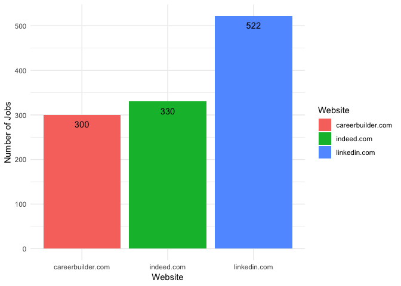

```r
jobs_cnt <- dbGetQuery(ds_job_db,
           "
SELECT DISTINCT
  W.WEBSITE as Website
  ,COUNT(DISTINCT J.JOB_ID) AS 'Number of Jobs'
FROM JOBS J
  INNER JOIN WEBSITE W ON J.WEBSITE_ID = W.WEBSITE_ID
GROUP BY
  W.WEBSITE
           "
           )

ggplot(jobs_cnt, aes(Website,`Number of Jobs`)) +
  geom_bar(stat = "identity", aes(fill=Website)) +
  theme_minimal() +
  geom_text(aes(label = `Number of Jobs`),vjust = 2)
```

### Top 25 Industries that on average request the most number of skills.

```r
s_avg <- dbGetQuery(ds_job_db,
           "
SELECT
  MAIN.INDUSTRY
  ,AVG(MAIN.COUNT) AS 'Average Number of Skills'
FROM (
  SELECT DISTINCT
    I.INDUSTRY
    ,J.JOB_ID
    ,COUNT(DISTINCT S.SKILLS_ID) AS COUNT
  FROM JOBS J
    INNER JOIN INDUSTRY I ON J.INDUSTRY_ID = I.INDUSTRY_ID
    INNER JOIN SKILLS S ON J.SKILLS_ID = S.SKILLS_ID
  GROUP BY
    I.INDUSTRY
    ,J.JOB_ID
) MAIN
WHERE
  MAIN.INDUSTRY IS NOT NULL
GROUP BY
  MAIN.INDUSTRY
ORDER BY
  AVG(MAIN.COUNT) DESC
LIMIT 25
           "
           )
knitr::kable(s_avg, format = "html")
```

| INDUSTRY | Average Number of Skills |
| --- | --- |
| Apparel & Fashion | 11.00000 |
| Aviation & Aerospace | 11.00000 |
| Banking | 11.00000 |
| Broadcast Media | 11.00000 |
| Business Supplies and Equipment | 11.00000 |
| Commercial Real Estate | 11.00000 |
| Consumer Electronics | 11.00000 |
| Defense & Space | 11.00000 |
| Education Management | 11.00000 |
| Gambling & Casinos | 11.00000 |
| Government Administration | 11.00000 |
| Health, Wellness and Fitness | 11.00000 |
| Hospitality | 11.00000 |
| Human Resources | 11.00000 |
| Industrial Automation | 11.00000 |
| Information Services | 11.00000 |
| Leisure, Travel & Tourism | 11.00000 |
| Mechanical or Industrial Engineering | 11.00000 |
| Mining & Metals | 11.00000 |
| Paper & Forest Products | 11.00000 |
| Public Relations and Communications | 11.00000 |
| Renewables & Environment | 11.00000 |
| Security and Investigations | 11.00000 |
| Accounting | 10.66667 |
| Financial Services | 10.55263 |